### Subsetting Samples

I needed to start by subsetting samples to test my script to make testing more efficient. I opted to used seqtk to subsample 10000 reads from each of the .fq.gz files:

```bash
seqtk sample -s100 [sample_name]_R1.fastq.gz 10000 > sub_[sample_name]_R1.fastq
seqtk sample -s100 [sample_name]_R2.fastq.gz 10000 > sub_[sample_name]_R2.fastq
```

### Quality of Reads and Alignment

Quality of Sequencing Reads (fastqc)

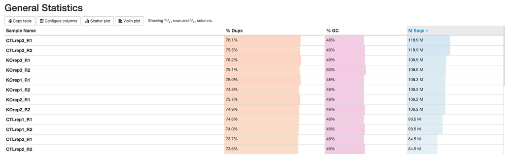

The read quality looks normal in terms of GC content and total reads (80-120 M). While the duplication levels would appear to be concerning, this is normal for RNAseq data since there tend to be some sequences that are highly expressed relative to most leading to high duplicates in fastQC. Read quality (per sequence and mean) also are all high ~35 so I would say that the read quality is good.

Quality of Alignment (flagstats)

[figure not shown]

The alignment does not show glaring issues. For all samples >90% of reads are uniquely mapped and there are very few unmapped reads.

Based on quality, I will not exclude any samples from the analysis.

### PCA and Clustering

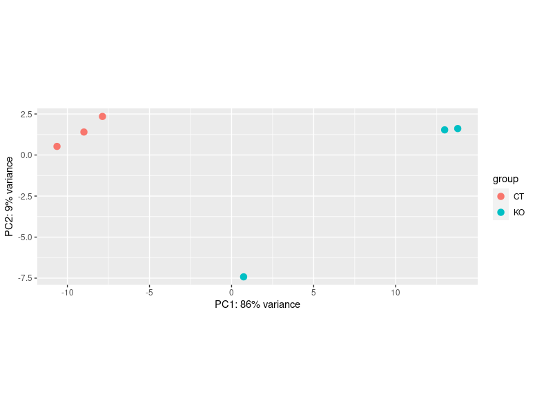

Clearly there is one KO sample that is different from the other two in terms of overall expression profile. This also is clear in the sample distance plot.

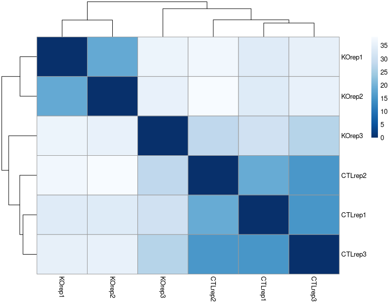

### Setting FDR and Determining Signifiance Genes

DESeq by default calculated the Benjamini-Hochberg adjusted p-values for results so I will use this method. The default alpha (false discovery rate) is 0.1. The method ranks all p-values and then calculated the adjusted p-value as (p-value)/(rank)*(number of tests). I tested a few different rates and saw slight variation in number of significantly DE genes, but will choose to use the default with the knowledge that this assumes 10% of the significnatly DE may be false positives.

With an FDR threshold of 0.1 there are 686 significantly upregulated genes and 822 significantly downregulated genes.

### Histogram of DE Genes

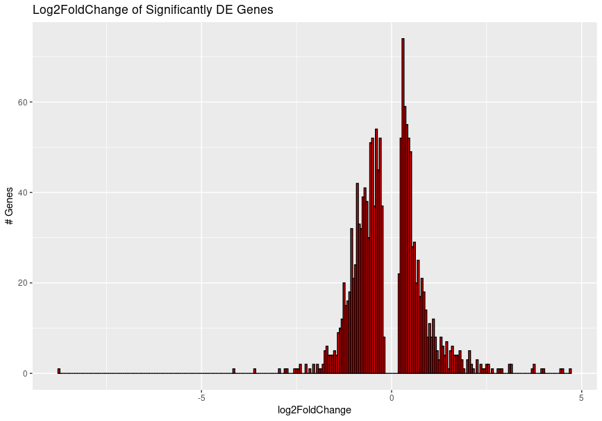

### Volcano Plot of DE Genes

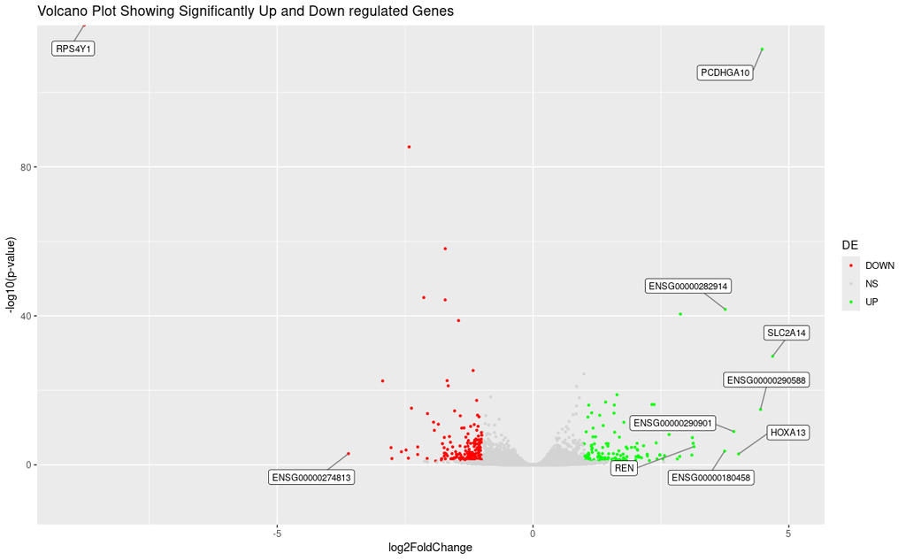

### GSEA Results

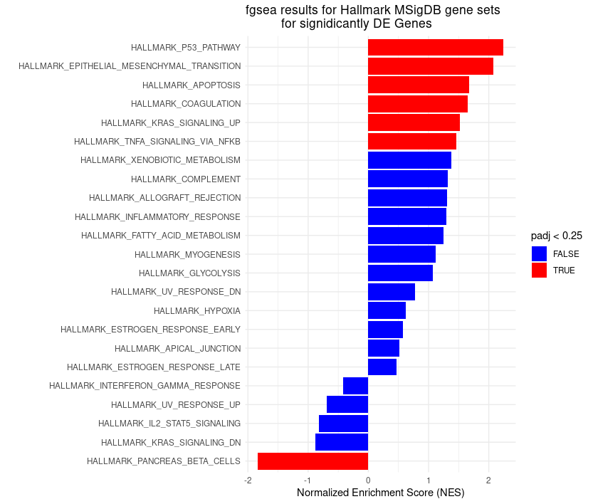

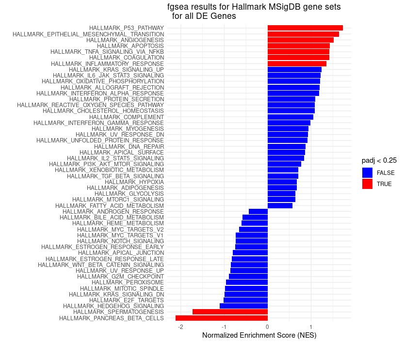

### enrichR Results

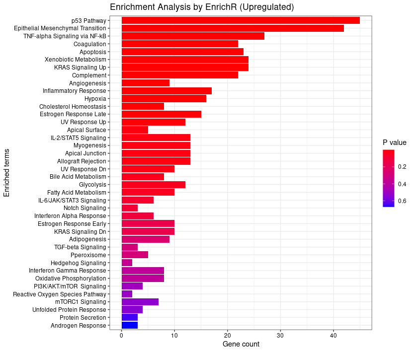

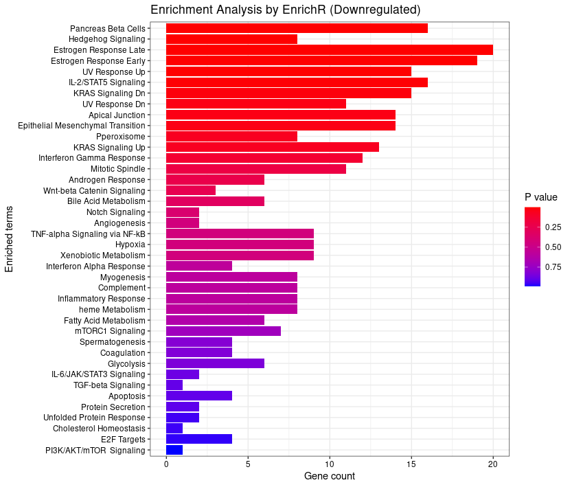

### Discussion of Results

I used the MSigDB Hallmark 2020 database for both the enrichR enrichment analysis and the GSEA. I used log2(foldchange) as a ranking metric for GSEA. Given that the enrichment analysis used the exact same genes as the GSEA with only significantly DE genes whereas the GSEA with all genes included more data, I am not surprised that the GSEA with only DE genes is more similar.